# Open Zoning Feed Specification

Data standards for describing zoning regulations, parcel geometry, and building characteristics

Authors

Affiliations

Carole Turley Voulgaris

Harvard Graduate School of Design

Kamryn Mansfield

Harvard Graduate School of Design

Houpu Li

Harvard Graduate School of Design

Paul Salama

Independent

Elizabeth Christoforetti

Havard Graduate School of Design

Abstract

Efforts to conduct detailed analysis of the variation in and consequences of zoning regulations have been hampered by the lack of standardized, machine-readable data on the requirements described in the texts of municipal zoning codes. Existing efforts to assemble data on zoning regulations have relied on database structures that are not well-suited to the complexity of zoning regulations. In this paper, we introduce and describe the Open Zoning Feed Specification (OZFS) standard as a recommended format for describing zoning regulations, parcel geometry, and building characteristics. We introduce a sample dataset that uses the OZFS standard to describe zoning regulations and parcel geometries for a set of 71 municipalities in the Dallas-Fort Worth region of Texas. The OZFS data standard offers a foundation on which software can be developed to analyze zoning regulations in greater detail than has previously been possible to do at a regional scale.

# Introduction

Zoning is the primary regulator of land use in the United States, yet the details of its provisions remain locked in hundred-page texts differing across thousands of jurisdictions. This opacity impacts not only scholars, advocates, and legislators, but also owners, architects, planners, and developers of all stripes. Recent atlas initiatives demonstrate that high-level variables such as permitted use or base density can be aggregated across jurisdictions, but those tabular compilations struggle to express the spatial, conditional, and mathematical rules that actually determine what may be built on an individual parcel.

This paper introduces the Open Zoning Feed Specification (OZFS), a data and geometry standard designed to encode zoning’s multi-dimensional logic in a form software can parse directly for parcel-level analysis. OZFS adopts a modular JSON/GeoJSON structure that stores numeric constraints, conditional expressions, and local definitions alongside district polygons, enabling automated feasibility checks for a single lot and scaleable aggregation to blocks, neighborhoods, or regions. OZFS treats zoning rules as structured data, an approach analogous to the General Transit Feed Specification in public transportation planning. Through this approach, OZFS seeks to improve the reproducibility of empirical research, lower the barriers and costs of due diligence for practitioners, and furnish decision-makers with a fine-grained basis for understanding land use.

# Prior work

Established open data standards for urban data include the General Transit Feed Specification (GTFS) and OpenStreetMaps (OSM).

OSM, an effort to assemble an open-source, digital map of the world, was established in 2004 (Open Street Map Contributors 2025b). It encodes data in an XML data format where all spatial features can be encoded as point locations and paths connecting points, with polygons represented as closed paths. A flexible free-tagging system (Open Street Map Contributors 2025a) allows an unlimited number of attributes to be specified to describe each feature, for example, by identifying a line as a road or as a fence and (for roads but not fences) specifying whether it permits bicycles.

GTFS was initially developed through a joint effort by Google and Portland TriMet in 2005 to facilitate incorporating transit route and schedule data into Google Maps’ trip-planning application (McHugh 2013). It encodes information about transit routes, stops, trips, and agencies as tabular data in a set of csv files. The data standard since has expanded to include additional tables (each in its own csv file) to include information about transit characteristics such as fares or pathways through stations. A strength of both of these efforts has been the use of a flexible data standard that can evolve to fully describe its subject while maintaining backwards-compatibility with data compiled under earlier versions of the standard.

Calls for a “GTFS for zoning” date back more than a decade (Salzberg 2013). While OSM allows for large-n analysis of street network topology (Boeing 2019) and GTFS likewise allows for analysis of transit service availability within neighborhoods and across cities (Voulgaris, Ray, and Fischer 2025; DeWeese et al. 2020), similar work analyzing zoning codes across jurisdiction remains time- and resource-prohibitive. Examples of the type of research and analysis that are stymied by the lack of standardized, machine-readable zoning data are studies by Conway (2021) and Monkkonen, Carlton, and Macfarlane (2020), which address the question of how statewide proposals to relax zoning restrictions in California might the production of housing in cities across the state (Monkkonen, Carlton, and Macfarlane 2020) or across the Los Angeles region (Conway 2021). Those analyses required strong assumptions with regards to, for example, allowable setbacks, since these data were not available in a consistent format for municipalities across the state. Such assumptions (derived from existing building envelopes) were not unreasonable and yielded sensible estimates of likely aggregate impacts. However, this approach would be less reliable for evaluating the feasibility of a particular prototype building on a particular parcel.

## Cross-jurisdictional zoning atlases

A few organizations have sought to compile zoning data across jurisdictions. The earliest of these that we have identified is the Zoning Atlas compiled by the Metropolitan Area Planning Council (MAPC), which is the regional planning agency for the Boston metropolitan area (Metropolitan Area Planning Council 2025). The MAPC Zoning Atlas includes data for 101 cities and towns in Massachussetts. MAPC began collecting data for its zoning atlas in 2012 and published its initial version in 2020 (Reardon, Partridge, and Perkins-High 2020). Their compiled zoning data are viewable through an interactive map and downloadable either as ESRI shapefiles or as csv files (both using a tabular data format).

National Zoning Atlas (NZA) represents the largest effort to compile harmonized zoning data and aims to decode zoning and similar regulations nationwide (National Zoning Atlas 2025b). Beginning with a spreadsheet template for Connecticut municipalities (Bronin and Ilyankou 2021), NZA now uses an internal data entry form (Bronin et al. 2023) and hosts an interactive map. Its controlled workflow has produced the largest publicly viewable corpus of zoning attributes in the United States. NZA does not publish downloadable datasets, although external contributors to the National Zoning Atlas are free to publish and share the data they provide to NZA (MAPC has contributed data from its Zoning Atlas to the broader NZA effort (National Zoning Atlas 2025a)). Some external contributors to the NZA have been funded by The Mercatus Center at George Mason University, which has published NZA data for nine states and regions as spreadsheets (csv or Excel) with accompanying geojson files on its website (Mercatus Center 2024).

Both the MAPC Zoning Atlas and the National Zoning Atlas have advanced comparative research and public transparency, yet their tabular formats place a limit on the number of attributes that can be defined for any zoning district. They also cannot easily encode conditional logic (e.g., setbacks dependent on street-fronting width) or divergent local definitions of “height,” “townhouse,” and other key terms. The Mercatus Center’s Zoning Atlas data dictionary (Kahn 2024) that notes this weakness in explaining that some numeric variables are encoded as strings because “it is very common for numeric variables in these datasets to have no single numeric value due to complex and context-dependent regulations within districts” (Kahn 2024, 1).

## Machine-readable zoning and automated feasibility tools

In the mid-2010s, a wave of venture-backed “proptech” start-ups—Envelope in New York, Flux’s Metro prototype in Austin, Gridics in Miami—showed that raw zoning text can be parsed into parcel-specific, three-dimensional massing or feasibility outputs. Each firm harbored desires to expand beyond their launch city and become a de facto national standard, yet the business case faltered, requiring additional bespoke services. Numerous more recent platforms, not limited to Deepblocks, UrbanForm, zlvas, and Zoneomics, continue the machine-readability push, but their internal data models remain closed. Collectively, these efforts prove the technical feasibility of automated code translation while underscoring the market need for an open, interoperable specification.

Zoneomics offers data through a paid API subscription. API outputs are in a json or geojson format, which offers the potential to overcome a weakness of a tabular data format: variables do not necessarily need to be stored for any districts they are not defined for. As noted by Kahn (2024) for NZA data published by the Mercatus Center, some variable values are necessarily encoded by text strings that describe constraints that may depend on land use or on characteristics of the building of the parcel, and these text strings cannot be consistently interpreted by software.

A limitation of the data structures used by all of the efforts described above is that they do not offer a consistent method for encoding constraints on the building form that are dependent on features of the building (e.g. when the required setback depends on the building height) or on features of the parcel (e.g. when the required setback depends on the the parcel width). Moreover, none of them differentiate between definitions of terms that may be used differently in different jurisdictions. For example, one jurisdiction might define height as the top of the roof for any structure, but another might define height (for particular roof types) as the midpoint between the top of the roof and the eave. As another example, zoning codes may have different setback requirements for multifamily homes and for townhomes, but a building that is defined as a multifamily building based on the definitions used in one jurisdiction might be defined as a row of townhomes in another. Another limitation is that, with exception of the Zoneomics API, all the efforts that provide downloadable data use a tabular data structure, which requires that any variable defined for any district in the dataset (or in the entire nation, if the goal is to compile a harmonized national dataset) must be defined (at least with a null value) for all districts.

## Toward an open zoning data standard

Inside individual proptech firms, bespoke JSON or GraphQL schemas presumably power automated tools and linked formulas. None, however, has been published as a public, versioned specification that cities, researchers, and software vendors can adopt without reinvention.

The Open Zoning Feed Specification (OZFS) addresses in this gap. It seeks to combine the machine-readability achieved by single-city startups with the cross-jurisdiction reach demonstrated by atlas projects, offering a modular JSON/GeoJSON feed that captures multi-dimensional, conditional rules as in the most robust open data standards.

# Contribution

The Open Zoning Feed Specification (OZFS) is offered as a scalable, extensible data schema for encoding residential zoning regulations at the parcel level in a way that is both machine-readable and jurisdiction-agnostic. OZFS is implemented in GeoJSON, a geographic extension of JSON that retains JSON’s nested flexibility. OZFS departs from legacy tabular formats by storing only those variables actually defined in a district and permitting new key–value pairs without changing the underlying schema.

OZFS makes six specific contributions:

1. Non-tabular structure. A hierarchical JSON model represents districts, bulk options (this is older OZ terminology. Not sure exactly how you describe now), and optional constraints, eliminating combinatorial explosion (alt. column-inflation) and redundant data entry.
2. Jurisdiction-specific definitions. Each feed contains an explicit glossary for locally defined terms—e.g., townhouse, multifamily, building height—so that uniform semantics are not imposed.
3. Python-syntax mathematical expressions. Controls may be stored as formulas (`MaxHeight` = 0.5 * `LotDepth`), allowing rules that reference parcel or building attributes.
4. Variable-referencing mechanism. Constraints can point to other variables in the same feed, supporting compound rules and one-time entry of shared values.
5. Embedded conditional logic. The schema accommodates context-dependent provisions (`if BuildingSetback ≥ 15 then MaxHeight = 35 else 30`) that spreadsheets cannot capture consistently.
6. Standards for describing parcels and buildings. While previous efforts have focused on encoding characteristics of zoning regulations, we argue that the usefulness of that data depends on the interactions among characteristics of individual parcels and proposed buildings. OZFS includes rules for consistently encoding information about regulations, buildings, and parcels.

These features support use cases that extend beyond aggregations and cross-jurisdictional comparison: mapping where a prototype multifamily home is permitted as-of-right across an entire region; pinpointing parcels whose irregular geometry or site conditions prevents them from reaching nominal entitlements; or simulating the parcel-level impact of relaxing yard requirements. Ultimately OZFS can be a data schema for crowd-sourced or large-language-model pipelines to ingest full zoning codes and emit consistent, interoperable OZFS feeds.

By releasing OZFS under a Creative Commons license, we aim to invite contribution and revision, much as the OpenStreetMap and GTFS data standards has evolved with stakeholder needs. We anticipate successive versions that refine residential typologies, incorporate a multiplicity of geospatial layers, and allow more complex spatial definitions. But the core principles—JSON hierarchy, explicit local definitions, formula and conditional support—are intended to remain stable so that automated ingestion and downstream analysis can rely on a consistent, open standard.

# OZFS Data Structures

The OZFS data standard includes three files:

## Zoning regulations

Zoning data are encoded in a separate *.zoning file for each municipality. The *.zoning file is formatted as a geojson file, which offers the advantages of a nested data structure. The specific structure of the *.zoning file is illustrated in Figure 1.

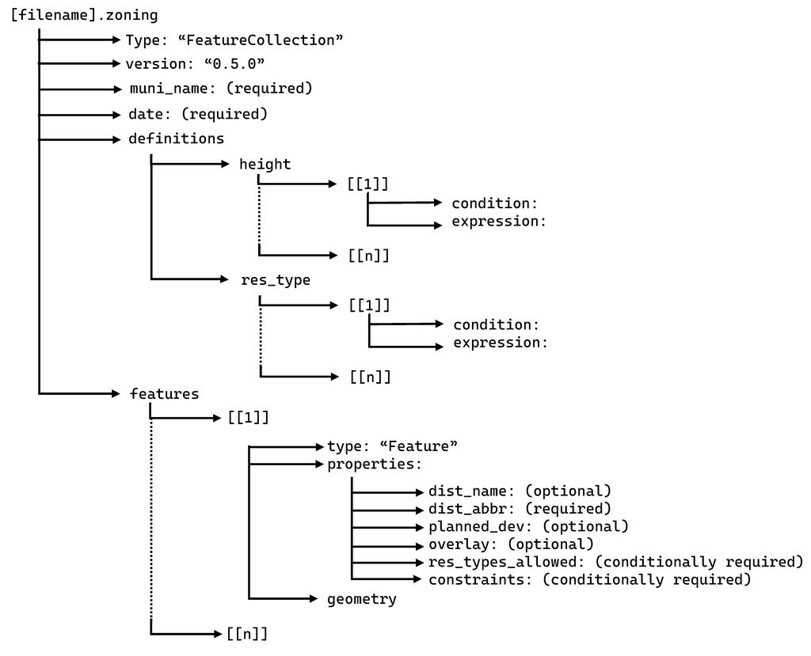

Figure 1: Structure of the zoning file

The top level of the file is an array with six key-value pairs:

- `Type`: As for geojson files, the value for this key should be “FeatureCollection.”
- `version`: The version of the OZFS data standard used in this file. The current version of the standard is 0.5.0.
- `muni_name`: The name of the municipality this zoning code refers to. This is a required value.
- `date`: The most recent date on which the zoning regulations are known to have been in effect. This is a required value.
- `definitions` is an array of definitions of terms (in the current version of the standard, height and residential building types) that may very from one municipality to the next and are defined in the text of the zoning code.
- `features` contains information on each zoning district, where each district is represented by an array of three elements: `type`, `properties`, and `geometry`. As for geojson files, the value for the `type` key will be “Feature” and the geometry key takes an array of coordinates describing the geometry of the feature (in this case, the district boundary). The value for the `properties` key is a list of key-value pairs that may include the following:
  - `dist_name` is the name of district. This value is optional.
  - `dist_abbr` is the abbreviated name of district. This value is required.
  - `planned_dev` is a binary value indicating whether this is a planned development district (where the entire district will be developed by a single developer who negotiates constraints directly with the municipality). This value is optional and is assumed to have a value of false if it is missing.
  - `overlay` indicates whether this district is an overlay district (a district that modifies the requirements of any base districts it overlaps) and (optionally) whether the overlay districts restricts or relaxes the requirements of its overlapping base district. This value is optional and is assumed to have a value of false (indicating that the district is not an overlay district) if it is missing. If it is an overlay district, it should have a value of “true,” “restrict” (to indicate that the overlay further restricts the requirements of the base district), or “relax” (to indicate that the overlay district relaxes the requirements of the base district).
  - `res_types_allowed` is a list of residential land uses that are allowed in the district. All values in the list must also appear in the `definitions` array. If this list of values is missing, it is assumed that no residential uses are allowed in the district. This list of values is not required if either the value of the `planned_dev` key or the value of the `overlay` key is true.
  - `constraints` is an array of constraints that define allowable building characteristics. The `constraints` key must be present if neither the value of the `planned_dev` key nor the value of the `overlay` key is true.

The definitions array (defined for the municipality as a whole) and the constraints array (defined for each district in the features array that is not a planned development district or an overlay district) are described in greater detail below.

### Constraints

Constraints are described by numeric values or expressions (in Python syntax) and are stored in the structure illustrated in Figure 2. Possible constraints include `setback_front` (the front setback), `far` (the floor area ratio), and `lot_cov_bldg` (the lot coverage). [Appendix A](https://vibe-lab-gsd.github.io/ozfs-standard/appendices/appendix-a.html) includes a complete list of constraints that have been defined for the *.zoning file, together with their descriptions. For each constraint that is included in the constraints array, a minimum value `min_val` and/or a maximum value `max_val` must be given.

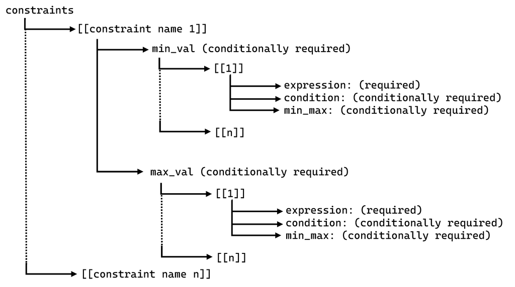

Figure 2: Data structure for constraints in the *.zoning file

Minimum and maximum values for constraints are stored as arrays including the following key-value pairs:

- `condition`: The condition under which the minimum or maximum value applies. This key is required if the number of elements in the min_value (or max_value) array is greater than one. The condition can be a logical expression (in Python syntax) defining the condition under which the minimum (or maximum) value applies. [Appendix B](https://vibe-lab-gsd.github.io/ozfs-standard/appendices/appendix-b.html) includes a full list of the of the variables that can be used in constraint and condition expressions, along with a description of each variable. If the condition under which the value applies cannot be described as a logical expression (one that evaluates to True or False) with one or more of those variables, it may be described in a text string (which will limit machine-readability).
- `expression`: These can either be constant numeric values or equations (in Python syntax) referring to variables listed in [Appendix B](https://vibe-lab-gsd.github.io/ozfs-standard/appendices/appendix-b.html). This can be a list of multiple values or expressions, in which case the `min_max` key should be used to specify whether the minimum or maximum value in the list should be used. If the value of the `condition` key is a text string that is not a logical expression, the value of the `expression` key may be a list of numbers (where the text string will describe the circumstances in which each number applies).
- `min_max`: This key is required if the list of expressions has a more than one element in it and `condition` is a logical expression (rather than just a free-form text string). It is a character string that can take one of two values: `min` or `max`. A value of `min` indicates that the governing constraint is the minimum of the possible values listed in the `expression` key. A value of `maximum` indicates that the governing constraint is the maximum of the possible values listed in the `expression` key.

The four examples below illustrate how zoning code text can be stored in the *.zoning file.

**Example 1: A single constraint value.** In Dallas, the minimum is side setback is specified for agricultural districts as follows:

> *Minimum side yard is 20 feet.* (City of Dallas 2024)

The corresponding *.zoning file input is shown in Figure 3.

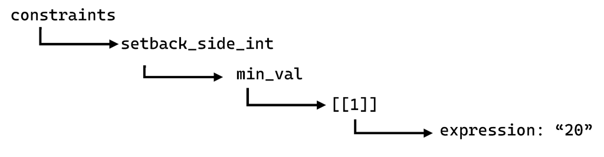

Figure 3: A single value for interior side setback requirement in Dallas, TX

**Example 2: Using min_max field.** For the Cockrell Hill Single-Family District, the minimum side setback depends on the length of the front footage.

> *No structure shall be closer to a side or rear lot line than five feet or a distance equal to 10% of the front footage of the lot, whichever distance shall be greater* (City of Cockrell Hill 2010, 13)

This requires a list of expressions for the minimum side and rear setbacks where the selected value should be the greater of the result of the two expressions. The corresponding *.zoning file input is shown in Figure 4.

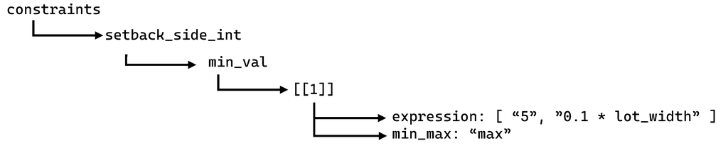

Figure 4: Using min_max field to describe interior side setback requirement in Cockrell Hill, TX

**Example 3: Multiple conditions.** Figure 5 from the Fort Worth Zoning Ordinance (City of Fort Worth, Texas 2007) shows how a district’s setback requirements are recorded when the value depends on the building height.

> *The height of a building in the “A” through “F” districts may be increased when the front, side and rear yard dimensions are each increased above the minimum requirements by one foot for each foot such building exceeds the height limit of the district in which it is located.*

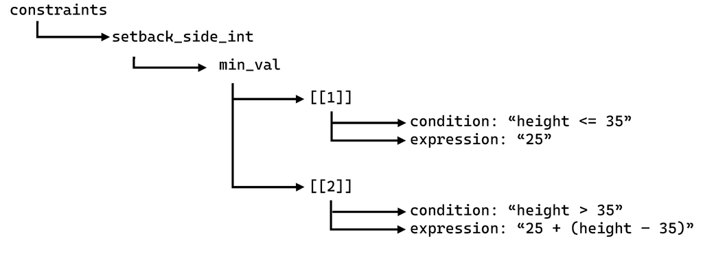

Figure 5: Multiple conditions for interior side setback requirement in Fort Worth, TX

**Example 4: Complex conditions.** While a software algorithm may not be able to interpret complex conditions like those listed for the Urban Center District in Addison (Town of Addison, Texas 2024), they can still be stored in the *.zoning file as shown in Figure 6. Note that the setback exceptions for parts of the block face were not encoded since the current OZFS standard assumes a relatively rectangular building with no specific orientation (this is discussed later in this paper under “Opportunities for future development”).

> *The build-to line for primary buildings, structures, walls and fences shall be ten feet on all public street frontages except along residential streets (category C) and residential mew streets (category D), which shall have build-to lines as established later in this section. Up to 25 percent of any street frontage of a building may vary from this build-to line, but shall not be less than five feet, nor more than 25 feet.*

> *The build-to line for residential streets (category C) shall be five feet where a building or structure fronts public open space. In all other cases along residential streets, a maximum of 75 percent of any block face may be constructed to the five-foot build-to line with the remainder of the block face being constructed no closer than eight feet, nor more than 25 feet from the R.O.W.*

> *The build-to line for residential mew streets (category D) shall be contiguous with the R.O.W. A minimum of 70 percent of the build-to line of any block or parcel must be occupied by buildings or parking structures.*

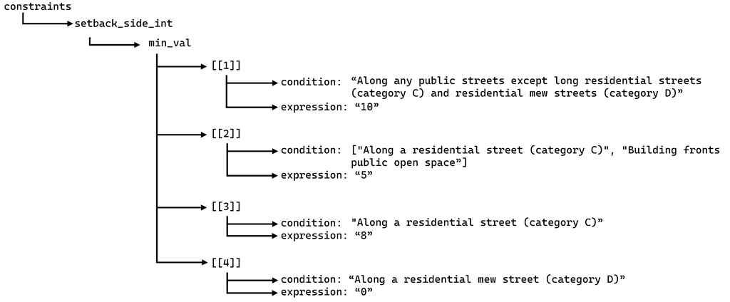

Figure 6: Complex conditions describing interior side setback requirement in Addison, TX

### Definitions

There may be terms that are used in many different zoning codes, but with definitions that vary across municipalities. The current version of the OZFS standard (version 0.5.0) requires definitions for height and for types of residential buildings. Other definitions may be added to future extensions of the standard.

For each definition, one or more arrays comprising conditions and expressions can be defined. The value of the `condition` key defines the circumstance under which the value of the `expression` key applies and should be a logical statement (one that returns a value of true or false) in Python syntax, referencing any of the variable names listed in [Appendix B](https://vibe-lab-gsd.github.io/ozfs-standard/appendices/appendix-b.html). The value of the `expression` key should be an equation (in Python syntax) referencing any of the variable names listed in [Appendix B](https://vibe-lab-gsd.github.io/ozfs-standard/appendices/appendix-b.html). As an example, if the height of a building is defined as the top of the highest wall plate for buildings with a flat roof type and the mid-point between the top of the roof and the eave for all roof types except a flat roof (see [Appendix C](https://vibe-lab-gsd.github.io/ozfs-standard/appendices/appendix-c.html) for an illustration of various roof types), the height definition would be coded as illustrated in Figure 7.

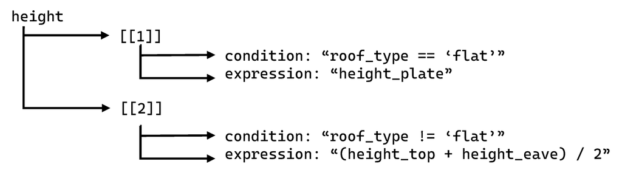

Figure 7: Illustrative example of a height definition

Conditions do not necessarily need to be mutually exclusive. When they are not, they are applied in the order in which they appear. For example, if the residential building type (`res_type`) of a building with three or more units is defined as `multifamily` building unless all units have outside entrances on the ground level, in which case it is defined as a `townhouse`, this could be encoded as illustrated in Figure 8. In that example, all buildings with only one dwelling unit would be defined as single-family. Of the remaining buildings, all buildings with two units would be defined as duplexes. Of the remaining buildings (all of which would have three or more dwelling units), those in which all units have an outside, ground-level entrances would be classified as townhouses, and all other buildings with three or more units would be classified as multifamily buildings.

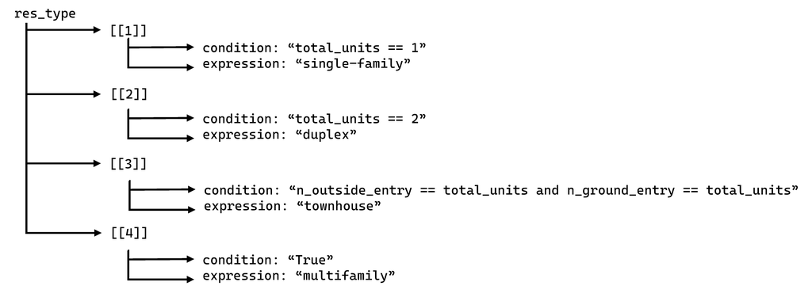

Figure 8: Illustrative example of a residential type definition

## Parcel geometry

Parcel geometry data representing parcel boundaries as polygons are commonly available in GIS files from state, county, or municipal open-data portals. These require pre-processing for zoning analysis because applying required setbacks to determine the buildable area of a parcel requires information not only about the shape and location of the parcel, but also about its orientation with respect to the street, since zoning codes may specify difference setbacks for the front, sides, and rear of a parcel, respectively.

In the OZFS data standard, parcels must be represented in a geojson file that includes, for each parcel, line strings representing each parcel edge (front, back, and side(s) and a point representing the parcel centroid. All features have a `parcel_id` key with a value that uniquely identifies which parcel each edge or centroid is associated with.

Each feature in the parcel dataset will also have a key, `side` , that can take one of six values:

- `front` indicates that this is a line string representing the front of a parcel.
- `rear` indicates that this is line string representing the rear of a parcel.
- `interior side` indicates that this is a line string representing the interior side of a parcel (the side adjacent to another parcel).
- `exterior side` indicates that this is a line string representing the exterior side of a parcel. Only a corner lot can have an exterior side. This is the side of a corner lot that is adjacent (and approximately parallel) to the street that is not indicated in the parcel’s address.
- `unknown` indicates that this is a line string representing the side of a parcel that has not been classified into one of the above categories (for irregular parcel geometries and/or parcels where the relationship to the adjacent street network is unclear).
- `centroid` indicates that this is a point representing the parcel’s centroid.

Parcel centroids have four additional key/value pairs:

- `lot_width` indicates the width of the parcel in feet.
- `lot_depth` indicates the depth of the parcel in feet.
- `lot_area` indicates the area of the parcel in acres.
- `vacant` takes a value of true or false and indicates whether the lot is vacant.

In addition to parcel geometry features, the *.parcel file must also include a `version` key indicating what version of the OZFS standard the file is consistent with. The version described in this paper is 0.5.0.

## Building characteristics

Building characteristics for a single building are stored in json file with the structure illustrated in Figure 9. The file includes three arrays:

- `bldg_info` includes information on the characteristics of the overall building (building dimensions and number of parking spaces within the structure).
- `unit_info` includes information in each type of unit within the building, and
- `level_info` contains information on each level within the building.

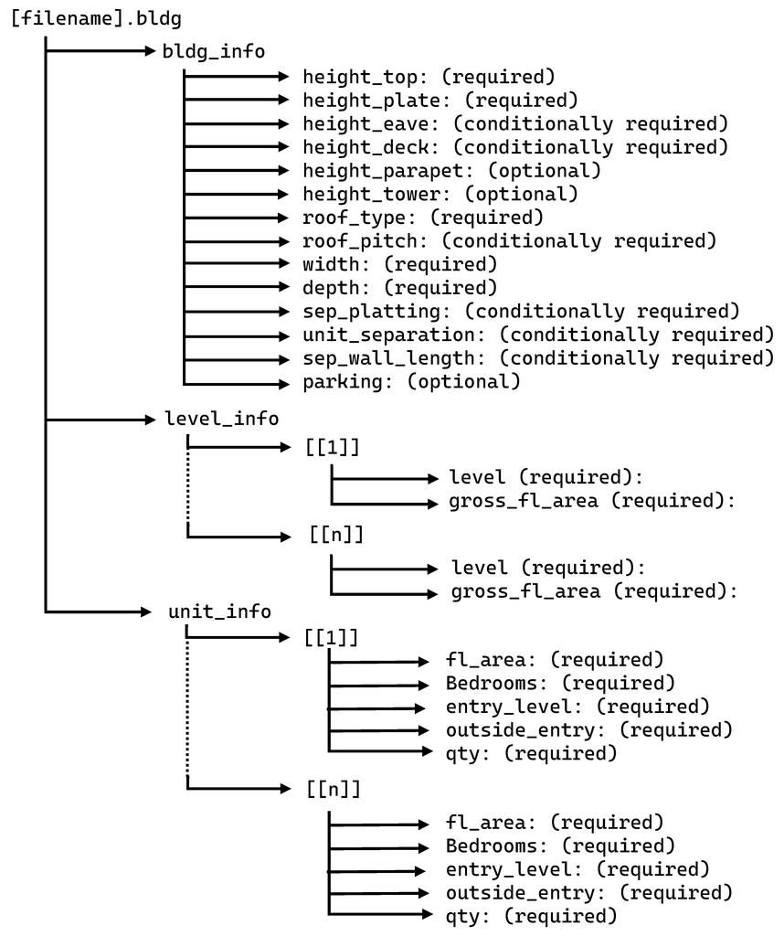

Figure 9: Structure of *.bldg file

### Building dimensions

All building dimensions are in feet. The building information array includes the height from the ground to the top of the building (`height_top`), from the ground to the highest wall plate (`height_plate`), as well as the building `width`, the building `depth`, and the building’s roof type (`roof_type`). Refer to [Appendix C](https://vibe-lab-gsd.github.io/ozfs-standard/appendices/appendix-c.html) for an illustration of roof types that are defined for use in OZFS.

As noted in the section on zoning constraints, there are differences among zoning codes with regards to how a building’s height is defined for various roof types. For roof types other than a flat roof, the eave height must be specified in the `height_eave` key, and the roof pitch must be specified in the `roof_pitch` key. For Mansard roofs, `height_deck` must be specified as well. For roofs with a parapet, the `height_parapet`, should also be added.

If the building includes towers, chimneys, antennas, or mechanical structures, the (maximum) height of these (from the roof) can optionally be specified with the `height_tower` key.

The `sep_platting` key is used to indicate whether each until in the building would be on a separately platted parcel and the `unit_separation` key describes how units are separated (by a “party_wall”, a “fire_wall”, or an “open_area”). If units are separated by a party wall or fire wall, the `sep_wall_length` key stores the length of the separation wall. These keys may be used to determine whether the building meet’s a municipality’s definition of a townhome. There is also an optional `parking` key to indicate the number of parking spaces contained within the building’s structure (i.e. in a garage).

### Level information

The level array includes, for each level of the building, a two-element array with the level number and the gross floor area (in square feet) of that level. Above-ground levels are numbered with positive sequential numbers beginning at one (for the lowest above-ground level), and below-ground level are numbered with numbers decreasing from negative one (for the level closest to the ground).

### Unit information

The unit array includes an array specifying the following characteristics for each unit type, where units are classified as being of the same type if they have the same values for each characteristic below:

- `fl_area`: The floor area of the unit in square feet.
- `bedrooms`: The number of bedrooms in the unit, expressed as a whole number with a minimum value of zero (for a studio unit).
- `entry_level`: The level number the entrance to the unit is on.
- `outside_entry`: A binary value indicating whether the entrance to the unit is directly from the outside of the building.

In addition to the four characteristics above, there is also a `qty` key to indicate how many units of each type are in the building.

# Sample Dataset

We have compiled a sample dataset with zoning regulations and parcel geometry for a set of 71 municipalities in the Dallas/Forth Worth region of Texas, as well as sample building characteristic data for four hypothetical residential buildings.

## Zoning regulations

The *zoning files were created using NZA data published by the Mercatus Center at George Mason University (Mercatus Center 2024) as a starting point. We converted that data for each of 71 cities in the Dallas-Forth Worth region into a *.zoning file consistent with the OZFS data standard. Textual notes in NZA fields were used to create key:value tags that were not represented by any NZA field and/or to formulate expressions to represent context-dependent constraints. [Appendix D](https://vibe-lab-gsd.github.io/ozfs-standard/appendices/appendix-d.html) offers a detailed description of process for converting data from the NZA data data format (as represented by the data published by Mercatus Center) to the OZFS data format. NZA data does not include municipality specific definitions for residential building types or for building heights. We added these definitions directly from their respective municipal zoning codes. We encoded the zoning regulations for the city of Dallas (which is not included in the data published by the Mercatus Center) directly from the zoning code text (Dallas City 2024).

The sample set of zoning regulations for 71 municipalities in the Dallas-Forth Worth region in available from the Harvard Dataverse (Voulgaris et al. 2025).

## Parcel geometry

The *.parcel files were derived from the 2024 Land Parcels page of the Texas Geographic Information Office (TxGIO) data hub parcel data (Various Appraisal Districts 2024) and from the road centerline files from the 2024 United States Census Bureau TIGER/Line Shapefiles (U.S. Census Bureau, Geography Division 2024). [Appendix E](https://vibe-lab-gsd.github.io/ozfs-standard/appendices/appendix-e.html) contains details on how the *.parcel files were assembled from these sources. and the *.parcel files themselves are available from the Harvard Dataverse (Voulgaris, Li, and Mansfield 2025).

## Building characteristics

We have also created sample *.bldg files for each of four hypothetical buildings: One two-unit building; two different four-unit buildings, and a twelve-unit building. These can be used as an example to guide the creation of *.bldg files for other proposed buildings. They can also be used to test applications intended to check whether a proposed building is allowable under existing zoning regulations on a particular parcel. These sample building files are available from the Harvard Dataverse (Voulgaris, Mansfield, and Li 2025).

# Opportunities for future development

This paper, including the accompanying appendices, represents a complete description of the data standard. The full text of the this paper (with appendices) can be found at https://github.com/vibe-lab-gsd/ozfs-standard. We welcome potential users and other interested parties to submit issues and/or pull requests with comments and suggestions to improve the usefulness of the data standard, or to note inaccuracies in the sample dataset.

Several important opportunities for improvement remain open for future versions:

## Overlay districts and spatially-defined modifiers

The current schema records all base districts and overlays together, identifying districts as overlays (and optionally indicates whether they restrict or relax base district regulations) but does not fully capture their regulations nor priority rules to help reconcile multiple overlays with the base district. Future work could:

- Allow multiple simultaneous overlays (e.g. “Downtown Core” + “Inclusionary Housing”);
- Include attributes that would establish precedence among overlapping districts so applications can resolve conflicts;
- Support geometry-based overlays defined mathematically, for example: “within a quarter mile of a transit station” or “2000 feet outside of an airport runway,” which may require the storage of official and unofficial environmental layers (wetlands, river fronts, flood plains, site grading) with rigor sufficient for zoning use.

The above approach could align with the method patented by Sigaty et al. (Sigaty et al. 2013).

## Additional constraint families

This implementation of OZFS prioritized constraints present in the Dallas-Fort Worth metropolitan area and those included in the National Zoning Atlas. The full extent of zoning constraint definitions is vast. Principle (2018) and Lehnerer (2009) have each attempted to provide exhaustive and irreducible lists. Extending the constraint dictionary beyond the initial set will be essential for ensuring broad applicability for the standard.

## Split districts

Where a parcel straddles two districts, jurisdictions differ on whether the parcel must be subdivided, may distribute entitlements, or must apply the most restrictive rule. A subsequent version could encode jurisdiction-specific precedence flags (e.g. “restrictive-prevails” vs “pro-rated FAR”) and/or per-municipality reconciliation logic.

## Site grade

The *.parcel file currently includes information about the two-dimensional geometry of each parcel, but does not include any information about grades and elevations. This information could be relevant for some zoning analysis where the grade might have an effect, for example, on how the height of a building is measured. Future extensions of the data standard could incorporate information about grades and elevations in the *.parcel file. Keys could also be added to the *.zoning file to specify how site grade might influence the definitions of building heights in each municipality. Our initial test cases were in the Dallas-Forth Worth region, where there is minimal variation in elevation.

## Building Representation

The current *.bldg file structure is only capable of describing rectangular buildings by encoding the width and depth of the building. A method to describe building’s with a more complex footprint could be explored in future versions of the data standard. This could potentially be accomplished by adding geometry to the *.bldg file in a similar way geometry is contained in the *.parcel file.

Another addition could include ways to describe the orientation of the building in both the *.bldg file and the *.zoning file. The current data standard assumes that the building can be oriented in any direction, but there may be cases where the zoning code requires the building to be oriented in a specific way. This addition would require distinguishing and labeling the sides of the building in the *.bldg file and adding building orientation constraints to the *.zoning file.

# Conclusion

This data standard represents an important step towards the development of scaleable, automated methods that can facilitate strategic increases in the supply of housing in the United States through their direct use by developers and policy-makers. It also offers researchers new opportunities to uncover the ways in which zoning regulations vary across the United States. We invite all interested parties to suggest improvements and modifications for future versions of the data standard, to use the OZFS to encode the zoning regulations of additional cities, and to develop software to analyze zoning data that is encoded in this format.

## References

Boeing, Geoff. 2019. “Urban Spatial Order: Street Network Orientation, Configuration, and Entropy.” *Applied Network Science* 4 (1): 1–19.

Bronin, Sara C., and Ilya Ilyankou. 2021. “How to Make a Zoning Atlas: A Methodology for Translating and Standardizing District-Specific Regulations.” Rochester, NY. https://doi.org/10.2139/ssrn.3996609.

Bronin, Sara C., Scott Markley, Aline Fader, and Evan Derickson. 2023. “How to Make a Zoning Atlas 2.0: The Official Methodology of the National Zoning Atlas.” Rochester, NY: Social Science Research Network. https://doi.org/10.2139/ssrn.4476927.

City of Cockrell Hill. 2010. “Zoning and Development Code.” https://www.cityofcockrellhill.us/DocumentCenter/View/389/ZONINGCODE2010-FULL.

City of Dallas. 2024. “Dallas City Code, Division 51A‑4.110: Residential District Regulations; Section 51A‑4.111: Agricultural [a(a)] District.” https://codelibrary.amlegal.com/codes/dallas/latest/dallas_tx/0-0-0-75272.

City of Fort Worth, Texas. 2007. “Appendix a — Zoning Regulations, *Fort Worth Code of Ordinances*.” https://codelibrary.amlegal.com/codes/ftworth/latest/ftworth_tx/0-0-0-32923; American Legal Publishing.

Conway, Matthew Wigginton. 2021. “If You Zone It, Who Will Come, and How Will They Travel? The Effects of Relaxed Zoning Regulations on Travel Behavior.” PhD thesis, United States – Arizona: Arizona State University. https://www.proquest.com/docview/2533144762/abstract/3AA6C787EA7A466DPQ/1.

Dallas City. 2024. *The Dallas City Code*. https://codelibrary.amlegal.com/codes/dallas/latest/dallas_tx/0-0-0-75159.

DeWeese, James, Leila Hawa, Hanna Demyk, Zane Davey, Anastasia Belikow, and Ahmed El-Geneidy. 2020. “A Tale of 40 Cities: A Preliminary Analysis of Equity Impacts of COVID-19 Service Adjustments Across North America.” *Findings*.

Kahn, Eli. 2024. “NZA Data Dictionary.” Fairfax, CA: Mercatus Center, George Mason University. https://www.mercatus.org/sites/default/files/2024-09/zoning_atlas_data_dictionary_1.pdf.

Lehnerer, Alex. 2009. *Grand Urban Rules*. 010 Publishers.

McHugh, Bibiana. 2013. “Pioneering Open Data Standards: The GTFS Story.” In *Beyond Transparency: Open Data and the Future of Civic Innovation*, edited by Brett Goldstein and Lauren Dyson, 1st edition, 125–36. San Francisco: Code for America Press.

Mercatus Center. 2024. “State and Regional Zoning Atlas Datasets Mercatus Center.” August 2024. https://www.mercatus.org/state-and-regional-zoning-atlas-datasets.

Metropolitan Area Planning Council. 2025. “MAPC Zoning Atlas MAPC Zoning Atlas.” 2025. https://zoningatlas.mapc.org/.

Monkkonen, Paavo, Ian Carlton, and Kate Macfarlane. 2020. “One to Four: The Market Potential of Fourplexes in California’s Single-Family Neighborhoods,” July. https://escholarship.org/uc/item/8gh2x0tj.

National Zoning Atlas. 2025a. “Massachusetts Zoning Atlas. National Zoning Atlas.” 2025. https://www.zoningatlas.org/massachusetts.

———. 2025b. “National Zoning Atlas. National Zoning Atlas.” May 12, 2025. https://www.zoningatlas.org.

Open Street Map Contributors. 2025a. “Tags.” February 27, 2025. https://wiki.openstreetmap.org/wiki/Tags.

———. 2025b. “History of OpenStreetMap.” July 4, 2025. https://wiki.openstreetmap.org/wiki/History_of_OpenStreetMap.

Principle. 2018. “PlaceCode: The Next Generation of Form-Based Codes.” 2018. https://www.principle.us/placecode.

Reardon, Tim, Jessie Partridge, and Lily Perkins-High. 2020. “Introduction to the Zoning Atlas.” Boston: Metropolitan Area Planning Councul. https://zoningatlas.mapc.org/reports/1.

Salzberg, Andrew. 2013. “Let’s Build an Open Zoning Data Standard. Andrew Salzberg.” February 22, 2013. https://andrewsalzberg.wordpress.com/2013/02/22/lets-build-an-open-zoning-data-standard/.

Sigaty, Todd Michael, Eugene Jerome Pasquarelli, Gregg Andrew Pasquarelli, Timothy Michael Martone, and Sarah Elizabeth Williams. 2013. “System and Method for 3-d Massing of a Building Envelope.” Google Patents.

Town of Addison, Texas. 2024. “Appendix a — Unified Development Code, *Code of Ordinances of the Town of Addison, Texas*.” https://library.municode.com/tx/addison/codes/code_of_ordinances?nodeId=APXAUNDECO; Municode.

U.S. Census Bureau, Geography Division. 2024. “TIGER/Line Shapefiles: Roads Layer (Äll Roads/̈ Linear Features).” Shapefile (GIS vector), downloaded from the 2024 TIGER/Line Shapefiles. https://www.census.gov/geographies/mapping-files/time-series/geo/tiger-line-file.html.

Various Appraisal Districts. 2024. “Land Parcels.” Web. https://data.geographic.texas.gov/collection/?c=d0f7da13-ab09-4994-a16f-d52589e2476e.

Voulgaris, Carole Turley, Houpu Li, and Kamryn Mansfield. 2025. “OZFS parcel data for 71 cities in the Dallas area.” Harvard Dataverse. https://doi.org/10.7910/DVN/VYFKEQ.

Voulgaris, Carole Turley, Kamryn Mansfield, and Houpu Li. 2025. “OZFS Sample Building Files.” Harvard Dataverse. https://doi.org/10.7910/DVN/B0P3Q7.

Voulgaris, Carole Turley, Kamryn Mansfield, Houpu Li, Lauren Ames Fischer, Yang Zhou, and Rimshi Agrawal. 2025. “OZFS zoning data for 71 cities in the Dallas area.” Harvard Dataverse. https://doi.org/10.7910/DVN/YMKPSO.

Voulgaris, Carole Turley, Rosalie Singerman Ray, and Lauren Ames Fischer. 2025. “Transit Board Diversity and Pandemic Service Cuts in Vulnerable Communities.” *Transportation Research Record* 2679 (2): 575–91.